# Social Determinants of VOC Exposure in US Adults: NHANES Study

### Survey Weighting

NHANES is a national survey assessing the health and nutritional status of many communities of US adults and children, and relies on complex sampling techniques to accurately weight their data to be representative of all communities. We will use svydesign to create a survey design object to analyze our associations.

```r
#NHANES Survey Weights
nhanesDesign <- svydesign(id = ~psu,
                          strata = ~strata,
                          weights = ~weights,
                          nest = TRUE,
                          data = nhanes,
                          na.action = na.omit)
#Specific Exposure Interest is in Xylenes - 2 major metabolites: MHA2, and MHA3+4
```

### Distribution of VOC exposures

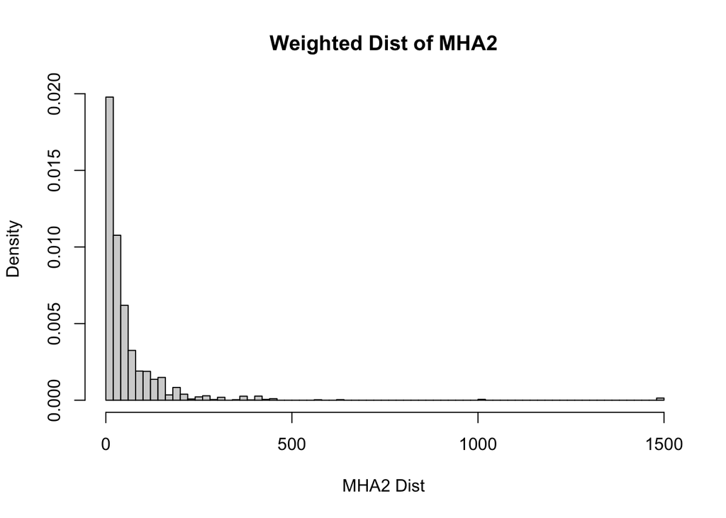

```r
#Descriptive Stats for VOC exposures
#MHA2
  MHA2.stats <- cbind(
    "wMEAN" = svymean(~MHA2, nhanesDesign, na.rm=TRUE),
    "wSD"= sqrt(svyvar(~MHA2, nhanesDesign, na.rm=TRUE)[1]),
          confint(svymean(~MHA2, nhanesDesign, na.rm=TRUE), df = degf(nhanesDesign)))
  MHA2.quantiles <- svyquantile(x = ~MHA2, design = nhanesDesign, na.rm = TRUE, quantiles = c(0.25, 0.5, 0.75))
  xrange.MHA2 <- range(nhanes$MHA2, finite=TRUE, na.rm=TRUE)
  MHA2.hist <- svyhist(~MHA2, nhanesDesign, xlim=xrange.MHA2, xlab = "MHA2 Dist", breaks = 80, main = "Weighted Dist of MHA2")
```

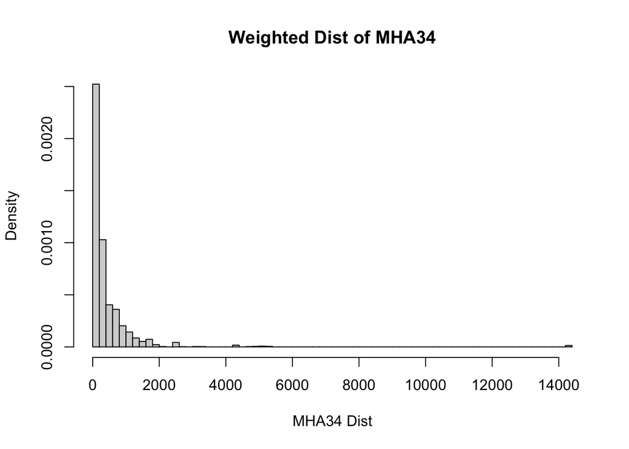

```r
#Median MHA2: 28.6

MHA2.stats <- cbind(
  "wMEAN" = svymean(~MHA2, nhanesDesign, na.rm=TRUE),
  "wSD" = sqrt(svyvar(~MHA2, nhanesDesign, na.rm=TRUE)[1]),
  confint(svymean(~MHA2, nhanesDesign, na.rm=TRUE), df = degf(nhanesDesign))
)

# Calculate weighted quantiles
MHA2.quantiles <- svyquantile(x = ~MHA2, design = nhanesDesign, na.rm = TRUE, quantiles = c(0.25, 0.5, 0.75))

# Create a boxplot using bwplot
MHA2.box <- bwplot(MHA2 ~ 1, data = nhanes, xlim=xrange.MHA2, weights = weights(nhanesDesign),
       main = "Boxplot of MHA2", xlab = "MHA2", ylab = "Values")


#MHA34
   MHA34.stats <- cbind(
    "wMEAN" = svymean(~MHA34, nhanesDesign, na.rm=TRUE),
    "wSD"= sqrt(svyvar(~MHA34, nhanesDesign, na.rm=TRUE)[1]),
          confint(svymean(~MHA34, nhanesDesign, na.rm=TRUE), df = degf(nhanesDesign)))
  MHA34.quantiles <- svyquantile(x = ~MHA34, design = nhanesDesign, na.rm = TRUE, quantiles = c(0.25, 0.5, 0.75))
  xrange.MHA34 <- range(nhanes$MHA34, finite=TRUE, na.rm=TRUE)
  MHA34.hist <- svyhist(~MHA34, nhanesDesign, xlim=xrange.MHA34, xlab = "MHA34 Dist", breaks = 80, main = "Weighted Dist of MHA34")
```

```r
#Median MHA34: 199
```

#### Descriptive Summary Table

We will assess key demographic and social variables of interest, including age, gender, education, race, industry category, income bracket, and urine metabolite concentrations (MHA2 and MHA3/4).

```r
#Summary Descriptive Table
 table1 <- tbl_svysummary(nhanesDesign, missing=NULL, missing_text="Missing",
    include = c(age, gender, education, race, industry.cat, income.short, MHA2, MHA34),
    statistic = list(all_continuous()  ~ "{mean} ({sd})",
                     all_categorical() ~ "{n}    ({p}%)"),
    digits = list(age ~ c(1, 1),
                  all_categorical() ~ c(0, 1))
  ) |>
  modify_header(label = "**Variable**") |>
  modify_caption("Weighted descriptive statistics") |>
  bold_labels()
table1
```

Weighted descriptive statistics

| **Variable** | **N = 131,457,147**<sup>1</sup> |
| --- | --- |
| age | 54.9 (16.3) |
| gender |  |
| men | 73,224,380 (55.7%) |
| women | 58,232,766 (44.3%) |
| education |  |
| Less Than 9th Grade | 7,074,120 (5.4%) |
| 9-11th Grade | 13,203,711 (10.1%) |
| High School Grad | 28,476,430 (21.7%) |
| Some College | 42,175,549 (32.2%) |
| College Grad | 40,019,755 (30.6%) |
| Refused | 0 (0.0%) |
| Don't Know | 17,985 (0.0%) |
| Missing | 489,597 |
| race |  |
| White | 100,632,186 (76.6%) |
| MexicanAmerican | 8,342,458 (6.3%) |
| Hispanic | 6,527,362 (5.0%) |
| Black | 8,858,315 (6.7%) |
| Other | 7,096,826 (5.4%) |
| industry.cat |  |
| Agriculture, Forestry, Fishing | 1,059,478 (1.5%) |
| Mining | 463,648 (0.7%) |
| Utilities | 795,188 (1.1%) |
| Construction | 5,266,967 (7.4%) |
| Manufacturing: Durable | 5,270,880 (7.4%) |
| Manufacturing: Non-Durable Goods | 3,713,720 (5.2%) |
| Wholesale Trade | 2,969,628 (4.2%) |
| Retail Trade | 4,920,183 (6.9%) |
| Transportation/Warehousing | 2,911,532 (4.1%) |
| Information | 1,781,988 (2.5%) |
| Finance, Insurance | 3,987,932 (5.6%) |
| Real Estate, Rental, Leasing | 1,831,324 (2.6%) |
| Professional, Technical Services | 6,298,781 (8.9%) |
| Management, Business, Cleaning/Waste Services | 3,696,788 (5.2%) |
| Education Services | 4,618,642 (6.5%) |
| Health Care, Social Assistance | 9,480,886 (13.3%) |
| Arts, Entertainment, Recreation | 1,628,790 (2.3%) |
| Accommodation, Food Services | 2,992,718 (4.2%) |
| Other Services | 3,339,664 (4.7%) |
| Private Households | 921,037 (1.3%) |
| Public Administration | 3,093,359 (4.4%) |
| Armed Forces | 0 (0.0%) |
| Missing | 60,414,014 |
| income.short |  |
| <$25K | 25,356,401 (19.3%) |
| $25-75K | 56,479,857 (43.0%) |
| >$75K | 49,620,889 (37.7%) |
| MHA2 | 59 (109) |
| Missing | 71,743,336 |
| MHA34 | 435 (935) |
| Missing | 69,612,710 |

<sup>1</sup> Mean (SD); n (%)

### VOC Exposure by Socio/Economic Factors

We will create a plot to assess the proportion of above/below median VOC levels by industry category and by type of environment for the job (whether it is indoors, hybrid, or outdoors).

#### Race

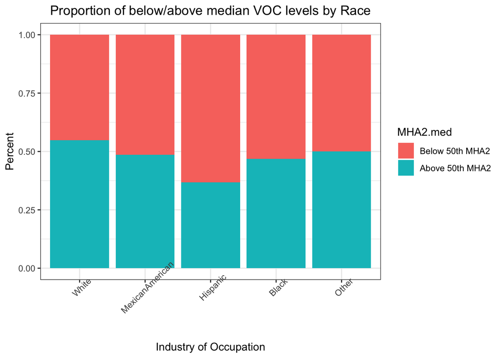

```r
nhanes.complete <- na.omit(nhanes)
#MHA2 Distribution by Race -
  #Barplot (proportion)
    MHA2.ggplot.race <- ggplot(data = nhanes.complete, aes(x = race, fill = MHA2.med)) +
    geom_bar(position = "fill") +
    ylab("Percent") +
    xlab("Industry of Occupation") +
    ggtitle("Proportion of below/above median VOC levels by Race") +
    theme_bw() +
    theme(axis.text.x = element_text(angle = 45), plot.title = element_text(hjust = 0.5))
  print(MHA2.ggplot.race)
```

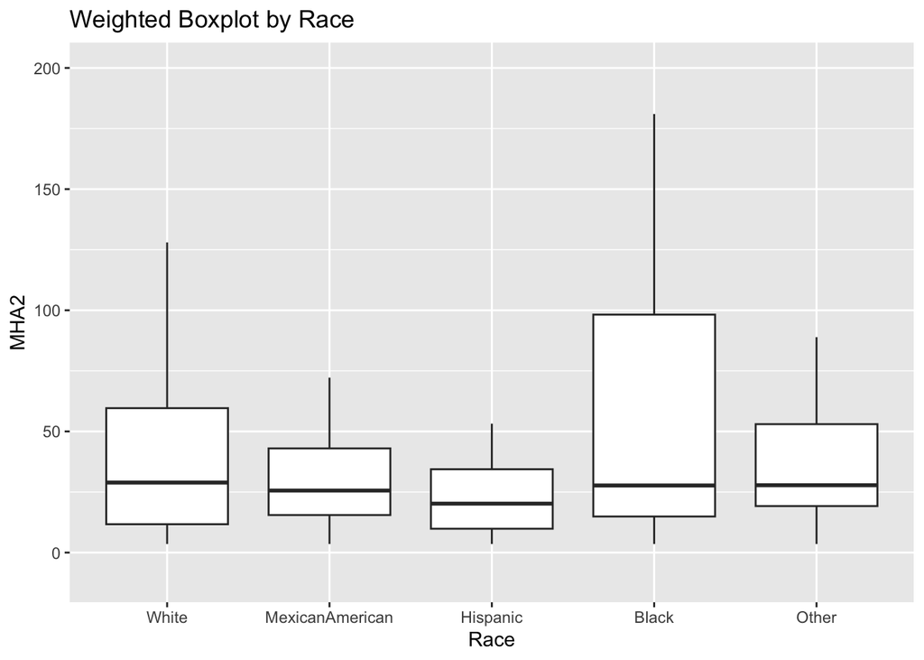

```r
  #Boxplot (MHA2 as continuous)
  y_limit <- c(-10, 200)
  MHA2.boxplot.race <- ggplot(data = nhanes.complete, aes(x = race, y = MHA2, weight = weights)) +
    geom_boxplot(outlier.shape = NA) +
    labs(x = "Race", y = "MHA2", title = "Weighted Boxplot by Race") +
  ylim(y_limit)
  print(MHA2.boxplot.race)
```

#### Industry

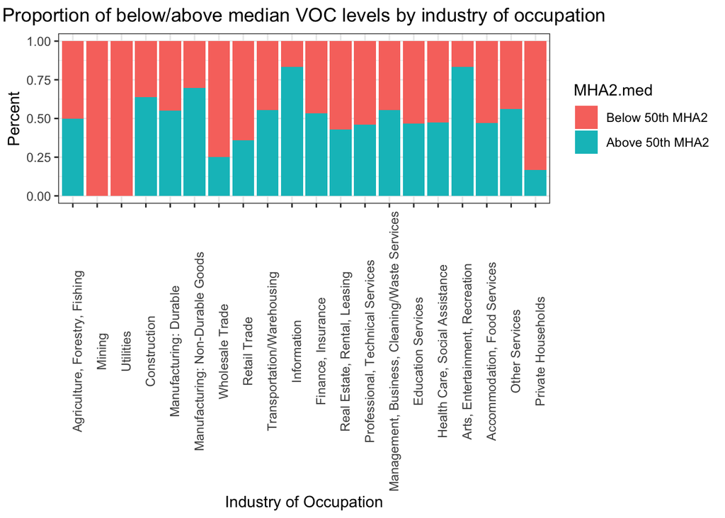

```r
#MHA2 Distribution by Industry
  #Barplot by Industry
    MHA2.ggplot.industry <- ggplot(data = nhanes.complete, aes(x = industry.cat, fill = MHA2.med)) +
    geom_bar(position = "fill") +
    ylab("Percent") +
    xlab("Industry of Occupation") +
    ggtitle("Proportion of below/above median VOC levels by industry of occupation") +
    theme_bw() +
    theme(axis.text.x = element_text(angle = 90), plot.title = element_text(hjust = 0.5))
  print(MHA2.ggplot.industry)
```

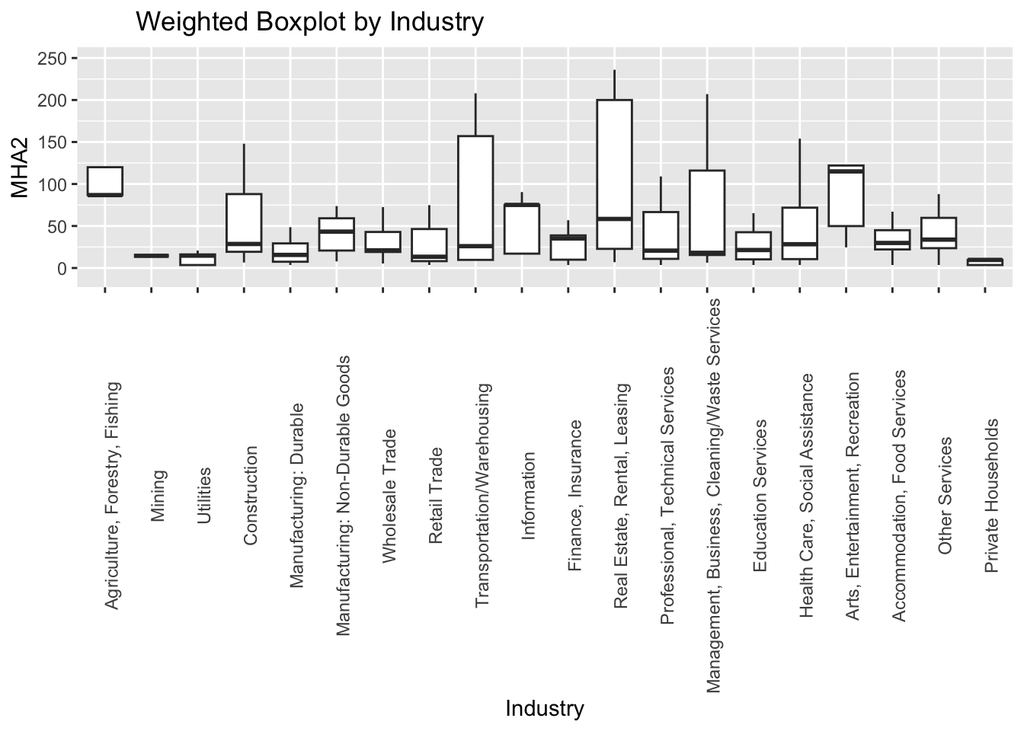

```r
  #Boxplot (MHA2 as continuous)
  y_limit <- c(-10, 250)
  MHA2.boxplot.industry <- ggplot(data = nhanes.complete, aes(x = industry.cat, y = MHA2, weight = weights)) +
    geom_boxplot(outlier.shape = NA) +
    labs(x = "Industry", y = "MHA2", title = "Weighted Boxplot by Industry") +
  ylim(y_limit) +
  theme(axis.text.x = element_text(angle = 90), plot.title = element_text(hjust = 0.1))
  print(MHA2.boxplot.industry)
```

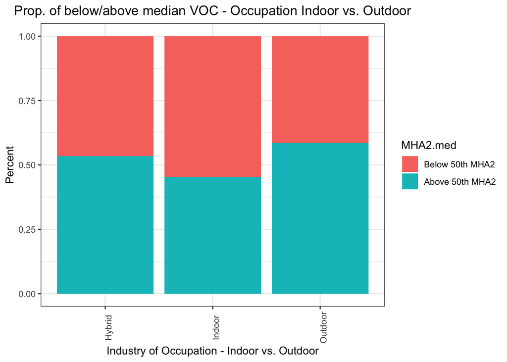

```r
#MHA2 Distribution by Industry (Indoor vs. Outdoor)
  #Barplot by Indoor vs. Outdoor Industry
    MHA2.ggplot.industry.inout <- ggplot(data = nhanes.complete, aes(x = industry.inout, fill = MHA2.med)) +
    geom_bar(position = "fill") +
    ylab("Percent") +
    xlab("Industry of Occupation - Indoor vs. Outdoor") +
    ggtitle("Prop. of below/above median VOC - Occupation Indoor vs. Outdoor") +
    theme_bw() +
    theme(axis.text.x = element_text(angle = 90), plot.title = element_text(hjust = 0.5))
  print(MHA2.ggplot.industry.inout)
```

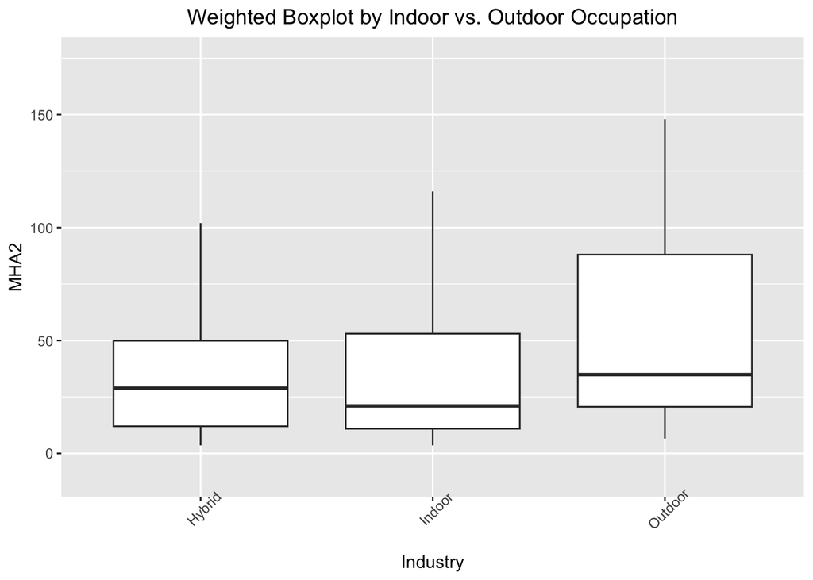

```r
  #Boxplot (MHA2 as continuous)
  y_limit <- c(-10, 175)
  MHA2.boxplot.industry.inout <- ggplot(data = nhanes.complete, aes(x = industry.inout, y = MHA2, weight = weights)) +
    geom_boxplot(outlier.shape = NA) +
    labs(x = "Industry", y = "MHA2", title = "Weighted Boxplot by Indoor vs. Outdoor Occupation") +
  ylim(y_limit) +
  theme(axis.text.x = element_text(angle = 45), plot.title = element_text(hjust = 0.5))
  print(MHA2.boxplot.industry.inout
  )
```

#### Education

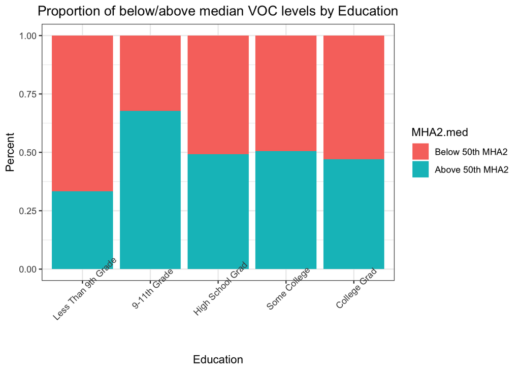

```r
#MHA2 Distribution by Education
  #Barplot by Education
    MHA2.ggplot.education <- ggplot(data = nhanes.complete, aes(x = education, fill = MHA2.med)) +
    geom_bar(position = "fill") +
    ylab("Percent") +
    xlab("Education") +
    ggtitle("Proportion of below/above median VOC levels by Education") +
    theme_bw() +
    theme(axis.text.x = element_text(angle = 45), plot.title = element_text(hjust = 0.5))
  print(MHA2.ggplot.education)
```

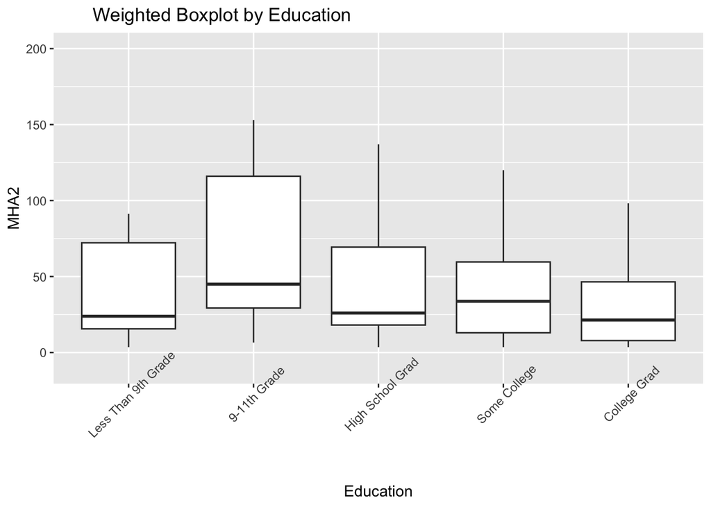

```r
  #Boxplot (MHA2 as continuous)
  y_limit <- c(-10, 200)
  ggplot(data = nhanes.complete, aes(x = education, y = MHA2, weight = weights)) +
    geom_boxplot(outlier.shape = NA) +
    labs(x = "Education", y = "MHA2", title = "Weighted Boxplot by Education") +
  ylim(y_limit) +
  theme(axis.text.x = element_text(angle = 45), plot.title = element_text(hjust = 0.1))
```

#### Income Bracket

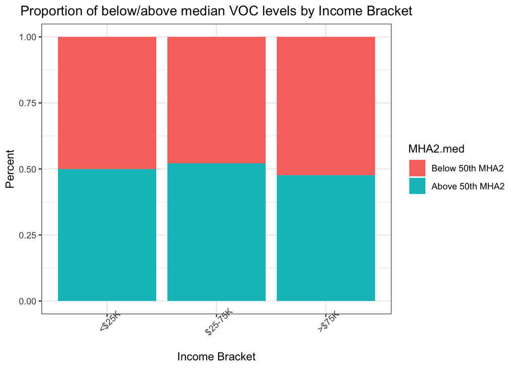

```r
#MHA2 Distribution by Income Bracket
  #Barplot by Income Bracket
  MHA2.ggplot.income <- ggplot(data = nhanes.complete, aes(x = income.short, fill = MHA2.med)) +
  geom_bar(position = "fill") +
  ylab("Percent") +
  xlab("Income Bracket") +
  ggtitle("Proportion of below/above median VOC levels by Income Bracket") +
  theme_bw() +
  theme(axis.text.x = element_text(angle = 45), plot.title = element_text(hjust = 0.5))
print(MHA2.ggplot.income)
```

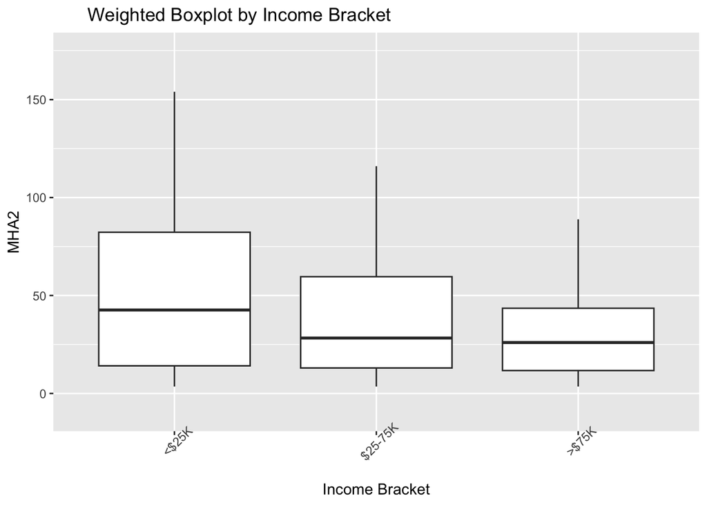

```r
  #Boxplot (MHA2 as continuous)
    y_limit <- c(-10, 175)
    ggplot(data = nhanes.complete, aes(x = income.short, y = MHA2, weight = weights)) +
      geom_boxplot(outlier.shape = NA) +
      labs(x = "Income Bracket", y = "MHA2", title = "Weighted Boxplot by Income Bracket") +
    ylim(y_limit) +
    theme(axis.text.x = element_text(angle = 45), plot.title = element_text(hjust = 0.1))
```

#### Gender

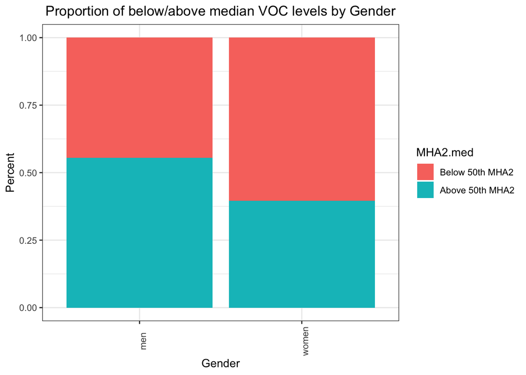

```r
#MHA2 Distribution by Gender
  MHA2.ggplot.gender <- ggplot(data = nhanes.complete, aes(x = gender, fill = MHA2.med)) +
  geom_bar(position = "fill") +
  ylab("Percent") +
  xlab("Gender") +
  ggtitle("Proportion of below/above median VOC levels by Gender") +
  theme_bw() +
  theme(axis.text.x = element_text(angle = 90), plot.title = element_text(hjust = 0.5))
  print(MHA2.ggplot.gender)
```

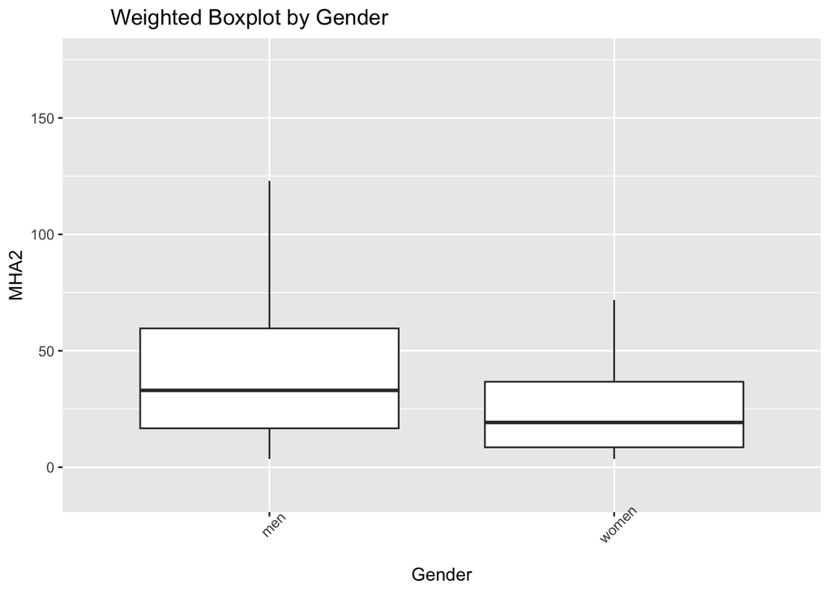

```r
   #Boxplot (MHA2 as continuous)
    y_limit <- c(-10, 175)
    MHA2.boxplot.gender <- ggplot(data = nhanes.complete, aes(x = gender, y = MHA2, weight = weights)) +
      geom_boxplot(outlier.shape = NA) +
      labs(x = "Gender", y = "MHA2", title = "Weighted Boxplot by Gender") +
    ylim(y_limit) +
    theme(axis.text.x = element_text(angle = 45), plot.title = element_text(hjust = 0.1))
  print(MHA2.boxplot.gender)
```

#### Evaluation of SES Factors and MHA2 Concentration

We initially ran Chi-Square tests for all categorical variables included, but our results determined that some of the assumptions may have been violated. Therefore, we used a Fisher’s exact test to determine out specific results.

```r
#Gender
fisher.mha2.gender <- fisher.test(table(nhanes$MHA2.med, nhanes$gender))
#Education
fisher.mha2.education.sim <- table(nhanes$MHA2.med, nhanes$education)
fisher.mha2.education <- fisher.test(fisher.mha2.education.sim, simulate.p.value = TRUE)
#Race
fisher.mha2.race.sim <- table(nhanes$MHA2.med, nhanes$race)
fisher.mha2.race <- fisher.test(fisher.mha2.race.sim, simulate.p.value = TRUE)
#Industry Category
fisher.mha2.industry.cat.sim <- table(nhanes$MHA2.med, nhanes$industry.cat)
fisher.mha2.industry.cat <- fisher.test(fisher.mha2.industry.cat.sim, simulate.p.value = TRUE)
#Income Bracket
fisher.mha2.income.short <- fisher.test(table(nhanes$MHA2.med, nhanes$income.short))
```